# main

```python
import matplotlib.pyplot as plt
import numpy as np
import pandas as pd
import seaborn as sns
import statistics as stats
from pathlib import Path
import os
```

```python
import kagglehub

# Download latest version
path = kagglehub.dataset_download("muqaddasejaz/european-flights-dataset")

print("Path to dataset files:", path)
```

```
Path to dataset files: C:\Users\FATHIR\.cache\kagglehub\datasets\muqaddasejaz\european-flights-dataset\versions\1
```

```python
import os

os.listdir(path)
```

```
['European Flights Dataset.csv']
```

```python
df = pd.read_csv(os.path.join(path, "European Flights Dataset.csv"))
df.head()
```

|  | YEAR | MONTH_NUM | MONTH_MON | FLT_DATE | APT_ICAO | APT_NAME | STATE_NAME | FLT_DEP_1 | FLT_ARR_1 | FLT_TOT_1 | FLT_DEP_IFR_2 | FLT_ARR_IFR_2 | FLT_TOT_IFR_2 | Pivot Label |
| --- | --- | --- | --- | --- | --- | --- | --- | --- | --- | --- | --- | --- | --- | --- |
| 0 | 2016 | 1 | JAN | 2016-01-01T00:00:00Z | EBAW | Antwerp | Belgium | 4 | 3 | 7 | NaN | NaN | NaN | Antwerp (EBAW) |
| 1 | 2016 | 1 | JAN | 2016-01-01T00:00:00Z | EBBR | Brussels | Belgium | 174 | 171 | 345 | 174.0 | 161.0 | 335.0 | Brussels (EBBR) |
| 2 | 2016 | 1 | JAN | 2016-01-01T00:00:00Z | EBCI | Charleroi | Belgium | 45 | 47 | 92 | 45.0 | 45.0 | 90.0 | Charleroi (EBCI) |
| 3 | 2016 | 1 | JAN | 2016-01-01T00:00:00Z | EBLG | Liège | Belgium | 6 | 7 | 13 | NaN | NaN | NaN | Liège (EBLG) |
| 4 | 2016 | 1 | JAN | 2016-01-01T00:00:00Z | EBOS | Ostend-Bruges | Belgium | 7 | 7 | 14 | NaN | NaN | NaN | Ostend-Bruges (EBOS) |

## 1. Check data

```python
df.isna().sum()
```

```
YEAR                  0
MONTH_NUM             0
MONTH_MON             0
FLT_DATE              0
APT_ICAO              0
APT_NAME              0
STATE_NAME            0
FLT_DEP_1             0
FLT_ARR_1             0
FLT_TOT_1             0
FLT_DEP_IFR_2    479785
FLT_ARR_IFR_2    479785
FLT_TOT_IFR_2    479785
Pivot Label           0
dtype: int64
```

```python
df.info()
```

```
<class 'pandas.DataFrame'>
RangeIndex: 688099 entries, 0 to 688098
Data columns (total 14 columns):
 #   Column         Non-Null Count   Dtype
---  ------         --------------   -----
 0   YEAR           688099 non-null  int64
 1   MONTH_NUM      688099 non-null  int64
 2   MONTH_MON      688099 non-null  str
 3   FLT_DATE       688099 non-null  str
 4   APT_ICAO       688099 non-null  str
 5   APT_NAME       688099 non-null  str
 6   STATE_NAME     688099 non-null  str
 7   FLT_DEP_1      688099 non-null  int64
 8   FLT_ARR_1      688099 non-null  int64
 9   FLT_TOT_1      688099 non-null  int64
 10  FLT_DEP_IFR_2  208314 non-null  float64
 11  FLT_ARR_IFR_2  208314 non-null  float64
 12  FLT_TOT_IFR_2  208314 non-null  float64
 13  Pivot Label    688099 non-null  str
dtypes: float64(3), int64(5), str(6)
memory usage: 116.4 MB
```

```python
df.duplicated().sum()
```

```
np.int64(0)
```

```python
df["APT_NAME"].nunique()
```

```
333
```

```python
df["STATE_NAME"].nunique()
```

```
42
```

## 2. Cleaning data

```python
ifr_cols = [
    "FLT_DEP_IFR_2",
    "FLT_ARR_IFR_2",
    "FLT_TOT_IFR_2"
]

df[ifr_cols] = df[ifr_cols].fillna(0)
```

Missing IFR values were previously filled with 0 for general preprocessing purposes. However, this may introduce unrealistic IFR ratios or zero-IFR airports in certain regions.

```python
df["FLT_DATE"] = pd.to_datetime(df["FLT_DATE"], errors="coerce")
```

```python
df = df.rename(columns={
    "FLT_DEP_1": "departure_flights",
    "FLT_ARR_1": "arrival_flights",
    "FLT_TOT_1": "total_flights",

    "FLT_DEP_IFR_2": "departure_ifr",
    "FLT_ARR_IFR_2": "arrival_ifr",
    "FLT_TOT_IFR_2": "total_ifr",

    "APT_NAME": "airport_name",
    "APT_ICAO": "airport_icao",
    "STATE_NAME": "country"
})

text_fixes = {
    "T\u00c3\u00bcrkiye": "Türkiye",
    "Atat\u00c3\u00bcrk": "Atatürk",
    "G\u00c3\u00b6k\u00c3\u00a7en": "Gökçen",
}

for col in ["airport_name", "country"]:
    for wrong, correct in text_fixes.items():
        df[col] = df[col].str.replace(wrong, correct, regex=False)

df["airport_country"] = (
    df["airport_name"] +
    " (" +
    df["country"] +
    ")"
)

df.head()
```

|  | YEAR | MONTH_NUM | MONTH_MON | FLT_DATE | airport_icao | airport_name | country | departure_flights | arrival_flights | total_flights | departure_ifr | arrival_ifr | total_ifr | Pivot Label | airport_country |
| --- | --- | --- | --- | --- | --- | --- | --- | --- | --- | --- | --- | --- | --- | --- | --- |
| 0 | 2016 | 1 | JAN | 2016-01-01 00:00:00+00:00 | EBAW | Antwerp | Belgium | 4 | 3 | 7 | 0.0 | 0.0 | 0.0 | Antwerp (EBAW) | Antwerp (Belgium) |
| 1 | 2016 | 1 | JAN | 2016-01-01 00:00:00+00:00 | EBBR | Brussels | Belgium | 174 | 171 | 345 | 174.0 | 161.0 | 335.0 | Brussels (EBBR) | Brussels (Belgium) |
| 2 | 2016 | 1 | JAN | 2016-01-01 00:00:00+00:00 | EBCI | Charleroi | Belgium | 45 | 47 | 92 | 45.0 | 45.0 | 90.0 | Charleroi (EBCI) | Charleroi (Belgium) |
| 3 | 2016 | 1 | JAN | 2016-01-01 00:00:00+00:00 | EBLG | Liège | Belgium | 6 | 7 | 13 | 0.0 | 0.0 | 0.0 | Liège (EBLG) | Liège (Belgium) |
| 4 | 2016 | 1 | JAN | 2016-01-01 00:00:00+00:00 | EBOS | Ostend-Bruges | Belgium | 7 | 7 | 14 | 0.0 | 0.0 | 0.0 | Ostend-Bruges (EBOS) | Ostend-Bruges (Belgium) |

```python
df = df.drop(columns=["Pivot Label"])

df = df.drop(columns=["MONTH_MON"])
```

```python
df["month_name"] = df["FLT_DATE"].dt.month_name()
df.head()
```

|  | YEAR | MONTH_NUM | FLT_DATE | airport_icao | airport_name | country | departure_flights | arrival_flights | total_flights | departure_ifr | arrival_ifr | total_ifr | airport_country | month_name |
| --- | --- | --- | --- | --- | --- | --- | --- | --- | --- | --- | --- | --- | --- | --- |
| 0 | 2016 | 1 | 2016-01-01 00:00:00+00:00 | EBAW | Antwerp | Belgium | 4 | 3 | 7 | 0.0 | 0.0 | 0.0 | Antwerp (Belgium) | January |
| 1 | 2016 | 1 | 2016-01-01 00:00:00+00:00 | EBBR | Brussels | Belgium | 174 | 171 | 345 | 174.0 | 161.0 | 335.0 | Brussels (Belgium) | January |
| 2 | 2016 | 1 | 2016-01-01 00:00:00+00:00 | EBCI | Charleroi | Belgium | 45 | 47 | 92 | 45.0 | 45.0 | 90.0 | Charleroi (Belgium) | January |
| 3 | 2016 | 1 | 2016-01-01 00:00:00+00:00 | EBLG | Liège | Belgium | 6 | 7 | 13 | 0.0 | 0.0 | 0.0 | Liège (Belgium) | January |
| 4 | 2016 | 1 | 2016-01-01 00:00:00+00:00 | EBOS | Ostend-Bruges | Belgium | 7 | 7 | 14 | 0.0 | 0.0 | 0.0 | Ostend-Bruges (Belgium) | January |

## 3. EDA

### 3.1 Which airport is the busiest?

```python
total_flights_by_airport = df.groupby("airport_country")["total_flights"].sum()
total_flights_by_airport.sort_values(ascending=False).head(20)
```

```
airport_country
Amsterdam - Schiphol (Netherlands)    2694025
Paris-Charles-de-Gaulle (France)      2581673
Frankfurt (Germany)                   2581524
London - Heathrow (United Kingdom)    2446474
Madrid - Barajas (Spain)              2117063
Munich (Germany)                      2013524
Barcelona (Spain)                     1699766
Istanbul Atatürk (Türkiye)            1570488
Rome - Fiumicino (Italy)              1518100
Zürich (Switzerland)                  1372321
London - Gatwick (United Kingdom)     1340097
Copenhagen - Kastrup (Denmark)        1335926
Oslo - Gardermoen (Norway)            1326722
Vienna (Austria)                      1324871
Istanbul Sabiha Gökçen (Türkiye)      1271627
Paris-Orly (France)                   1200973
Stockholm - Arlanda (Sweden)          1198195
Brussels (Belgium)                    1178495
Dublin (Ireland)                      1161078
Athens (Greece)                       1133781
Name: total_flights, dtype: int64
```

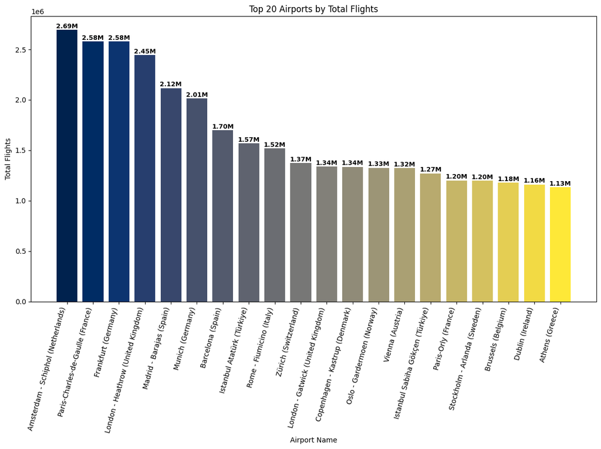

```python
colors = plt.cm.cividis(
    np.linspace(0, 1, 20)
)

plt.figure(figsize=(12, 9))
plt.bar(total_flights_by_airport.sort_values(ascending=False).head(20).index,
        total_flights_by_airport.sort_values(ascending=False).head(20).values,
        color=colors)


for i, value in enumerate(total_flights_by_airport.sort_values(ascending=False).head(20).values):
    plt.text(
        i,
        value + 1000,
        f"{value / 1_000_000:.2f}M",
        ha='center',
        va='bottom',
        fontsize=9,
        fontweight='bold'
    )

plt.xticks(rotation=75, ha='right')
plt.title("Top 20 Airports by Total Flights")
plt.xlabel("Airport Name")
plt.ylabel("Total Flights")
plt.tight_layout()

os.makedirs("plots", exist_ok=True)
filepath = os.path.join("plots", "total_flights_by_airport.png")
plt.savefig(filepath, dpi=300, bbox_inches="tight", facecolor="white")
```

### Insight from Sections 3.1-3.2

Amsterdam Schiphol Airport recorded the highest total flight activity among all airports in the dataset. However, the Netherlands did not rank as the country with the highest overall flight traffic in Europe.

This suggests that Dutch air traffic is highly concentrated around a single major hub airport. In contrast, countries such as Germany, France, Spain, the United Kingdom, and Türkiye show a more distributed aviation network, where flight activity is spread across multiple major airports rather than dominated by one central hub.

Together, France, Germany, Spain, and the United Kingdom account for nearly half of total European flight activity (48.37%), indicating that major European aviation activity is heavily concentrated in Western Europe.

### 3.2 Which country has the busiest flight activity?

```python
country_flights = (
    df.groupby("country")["total_flights"]
    .sum()
    .sort_values(ascending=False)
)
country_flights.head(20)
```

```
country
Spain             10858755
Germany           10710416
United Kingdom    10571729
France             9980740
Italy              6286032
Türkiye            5680924
Norway             3620616
Netherlands        2958470
Greece             2647744
Switzerland        2371676
Portugal           2257204
Poland             2179193
Belgium            1823046
Sweden             1817112
Austria            1784124
Ireland            1479569
Denmark            1335926
Finland             929047
Czech Republic      819299
Romania             661660
Name: total_flights, dtype: int64
```

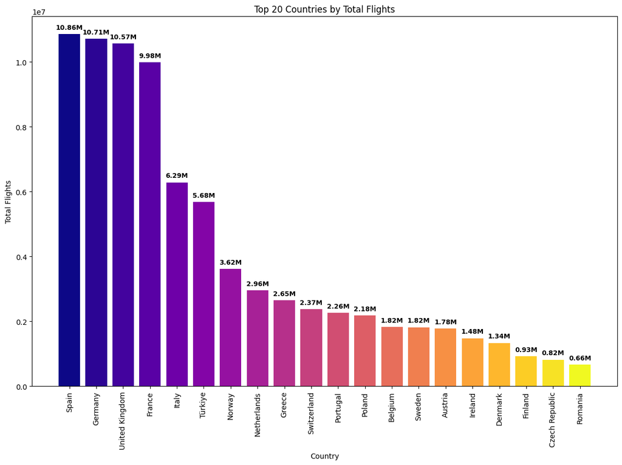

```python
colors = plt.cm.plasma(
    np.linspace(0, 1, 20)
)

plt.figure(figsize=(12, 9))
plt.bar(country_flights.sort_values(ascending=False).head(20).index,
        country_flights.sort_values(ascending=False).head(20).values,
        color=colors)

for i, value in enumerate(country_flights.sort_values(ascending=False).head(20).values):
    plt.text(
        i,
        value + 100000,
        f"{value / 1_000_000:.2f}M",
        ha='center',
        va='bottom',
        fontsize=9,
        fontweight='bold'
    )

plt.xticks(rotation=90)
plt.title("Top 20 Countries by Total Flights")
plt.xlabel("Country")
plt.ylabel("Total Flights")
plt.tight_layout()

os.makedirs("plots", exist_ok=True)
filepath = os.path.join("plots", "total_country_flights.png")
plt.savefig(filepath, dpi=300, bbox_inches="tight", facecolor="white")
```

```python
target_countries = ["United Kingdom", "Germany", "France", "Spain"]

# Total flights per negara
country_flights = (
    df[df["country"].isin(target_countries)]
    .groupby("country")["total_flights"]
    .sum()
    .reset_index()
    .sort_values(by="total_flights", ascending=False)
)

# Total seluruh penerbangan
total_all_flights = df["total_flights"].sum()

# Hitung persentase kontribusi
country_flights["percentage"] = (
    country_flights["total_flights"] / total_all_flights * 100
)

# Rapihin persen
country_flights["percentage"] = (
    country_flights["percentage"].round(2)
)

country_flights
```

|  | country | total_flights | percentage |
| --- | --- | --- | --- |
| 2 | Spain | 10858755 | 12.47 |
| 1 | Germany | 10710416 | 12.30 |
| 3 | United Kingdom | 10571729 | 12.14 |
| 0 | France | 9980740 | 11.46 |

### Network Structure Insight

- The Netherlands relies heavily on one dominant international hub: Amsterdam Schiphol Airport.
- Germany, France, Spain, and the United Kingdom show broader multi-airport networks, with major traffic distributed across several large airports.
- This difference helps explain why the busiest airport and the busiest country are not necessarily the same.

### 3.3 Which month is the busiest?

```python
month_order = [
    "January", "February", "March",
    "April", "May", "June",
    "July", "August", "September",
    "October", "November", "December"
]

monthly_flights = (
    df.groupby("month_name")["total_flights"]
    .sum()
    .reindex(month_order)
)

monthly_flights
```

```
month_name
January      6982208
February     6655653
March        7185807
April        7106667
May          7902728
June         7087768
July         8063220
August       8236009
September    7922637
October      7577217
November     6200505
December     6136119
Name: total_flights, dtype: int64
```

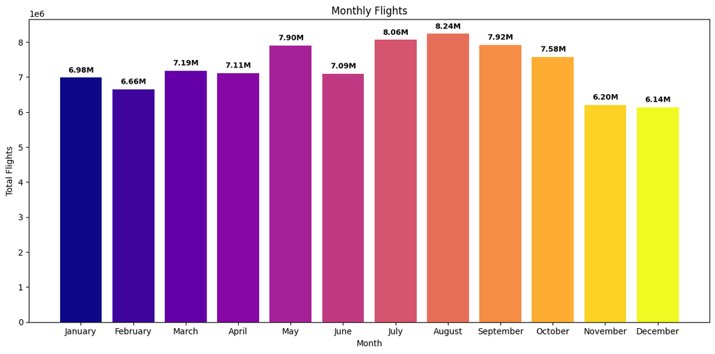

```python
colors = plt.cm.plasma(
    np.linspace(0, 1, len(monthly_flights))
)

plt.figure(figsize=(12, 6))

bars = plt.bar(
    monthly_flights.index,
    monthly_flights.values,
    color=colors
)

plt.title("Monthly Flights")
plt.xlabel("Month")
plt.ylabel("Total Flights")

for i, value in enumerate(monthly_flights.values):
    plt.text(
        i,
        value + 100000,   # offset biar teks naik sedikit
        f"{value / 1_000_000:.2f}M",
        ha='center',
        va='bottom',
        fontsize=9,
        fontweight='bold'
    )

plt.tight_layout()

os.makedirs("plots", exist_ok=True)

filepath = os.path.join(
    "plots",
    "monthly_flights.png"
)

plt.savefig(
    filepath,
    dpi=300,
    bbox_inches="tight",
    facecolor="white"
)

plt.show()
```

### 3.4 Top 15 Countries Flight Traffic by Month

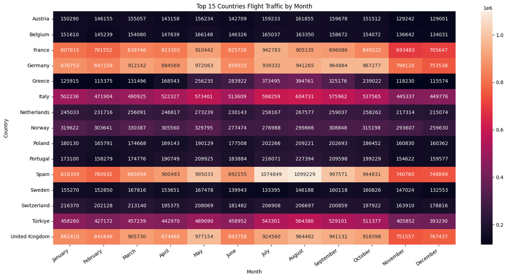

```python
top_15 = (
    df.groupby('country')['total_flights']
    .sum()
    .sort_values(ascending=False)
    .head(15)
    .index
)

filtered_df = df[df['country'].isin(top_15)]

pivot = filtered_df.pivot_table(
    values='total_flights',
    index='country',
    columns='month_name',
    aggfunc='sum'
)

month_order = [
    'January', 'February', 'March',
    'April', 'May', 'June',
    'July', 'August', 'September',
    'October', 'November', 'December'
]

pivot = pivot[month_order]

plt.figure(figsize=(16,8))

sns.heatmap(
    pivot,
    annot=True,
    fmt='.0f'
)

plt.title('Top 15 Countries Flight Traffic by Month')
plt.xlabel('Month')
plt.xticks(rotation=35, ha='right')
plt.ylabel('Country')

filepath = os.path.join("plots", "heatmap_country_vs_monthly_flights.png")
plt.savefig(filepath, dpi=300, bbox_inches="tight", facecolor="white")
plt.tight_layout()
```

Most countries show a consistent seasonal flight pattern, where air traffic gradually increases toward summer and peaks around July–August before declining again near the end of the year.

This recurring pattern appears across multiple European countries, suggesting that flight activity in Europe is strongly influenced by seasonal tourism and summer travel demand.

Tourism-oriented countries such as Greece, Spain, and Portugal show particularly strong increases during peak summer months.

### 3.5 Box plot total flights per country

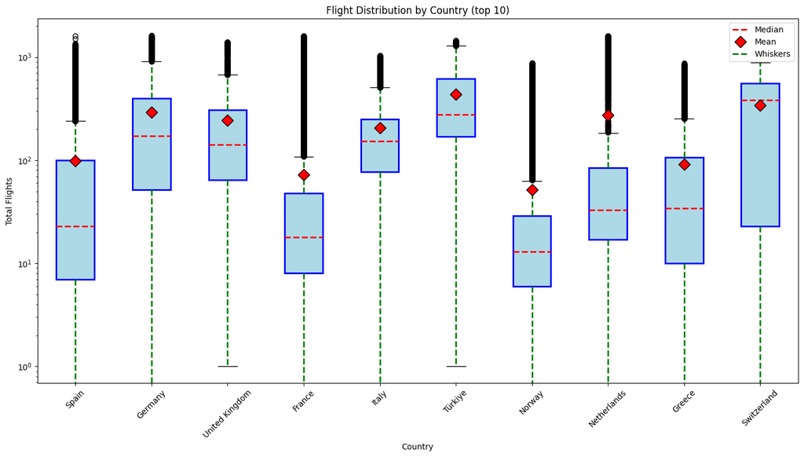

```python
from matplotlib.lines import Line2D

top_10 = (
    df.groupby('country')['total_flights']
    .sum()
    .sort_values(ascending=False)
    .head(10)
    .index
)

filtered_df = df[df['country'].isin(top_10)]

plt.figure(figsize=(14,8))

box = plt.boxplot(
    [filtered_df[filtered_df['country'] == country]['total_flights'] for country in top_10],
    labels=top_10, patch_artist=True, showmeans=True, medianprops={'color': 'red', 'linewidth': 2, 'linestyle': '--', 'label': 'Median'},
    whiskerprops={'color': 'green', 'linewidth': 2, 'linestyle': '--', 'label': 'Whiskers'},
    meanprops={
        "marker" : "D",
        "markerfacecolor" : "red",
        "markeredgecolor" : "black",
        "markersize" : 10,
        "label" : "Mean"
    }
)

legend_elements = [

    Line2D(
        [0],
        [0],
        color='red',
        linestyle='--',
        linewidth=2,
        label='Median'
    ),

    Line2D(
        [0],
        [0],

        marker='D',
        color='white',
        markerfacecolor='red',
        markeredgecolor='black',
        markersize=10,
        label='Mean'
    ),

    Line2D(
        [0],
        [0],
        color='green',
        linestyle='--',
        linewidth=2,
        label='Whiskers'
    )
]

for b in box['boxes']:
    b.set(color='blue', linewidth=2)
    b.set(facecolor='lightblue')

plt.title('Flight Distribution by Country (top 10)')
plt.xlabel('Country')
plt.ylabel('Total Flights')
plt.legend(handles=legend_elements, loc='upper right')
plt.xticks(rotation=45)
plt.yscale('log')
plt.tight_layout()

filepath = os.path.join("plots", "boxplot_country_flight_distribution.png")
plt.savefig(filepath, dpi=300, bbox_inches="tight", facecolor="white")
plt.show()
```

Most countries show highly skewed flight distributions with many extreme outliers. In several countries, the mean is noticeably higher than the median, indicating that a small number of airports handle disproportionately large amounts of air traffic compared to others.

### 3.6 Trend per year

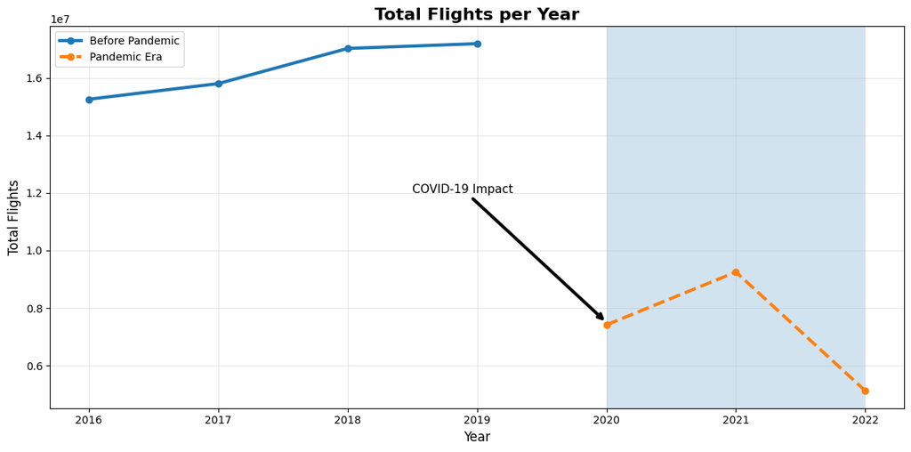

```python
flight_per_year = (
    df.groupby("YEAR")["total_flights"]
    .sum()
    .reset_index()
)

# Pisah data
before_pandemic = flight_per_year[flight_per_year["YEAR"] <= 2019]
pandemic = flight_per_year[flight_per_year["YEAR"] >= 2020]

plt.figure(figsize=(12, 6))

# Sebelum pandemi
plt.plot(
    before_pandemic["YEAR"],
    before_pandemic["total_flights"],
    marker="o",
    linewidth=3,
    label="Before Pandemic"
)

# Saat pandemi
plt.plot(
    pandemic["YEAR"],
    pandemic["total_flights"],
    marker="o",
    linewidth=3,
    linestyle="--",
    label="Pandemic Era"
)

# Highlight area pandemi
plt.axvspan(2020, 2022, alpha=0.2)

# Annotation
plt.annotate(
    "COVID-19 Impact",
    xy=(2020, 7500000),
    xytext=(2018.5, 12000000),
    arrowprops=dict(arrowstyle="->", lw=3),
    fontsize=11
)

# Styling
plt.title("Total Flights per Year", fontsize=16, weight="bold")
plt.xlabel("Year", fontsize=12)
plt.ylabel("Total Flights", fontsize=12)

plt.xticks(flight_per_year["YEAR"])
plt.grid(alpha=0.3)
plt.legend()
plt.tight_layout()

filepath = os.path.join("plots", "total_flights_per_year.png")
plt.savefig(filepath, dpi=300, bbox_inches="tight", facecolor="white")

plt.show()
```

### 3.7 Monthly Total Flights Over Time

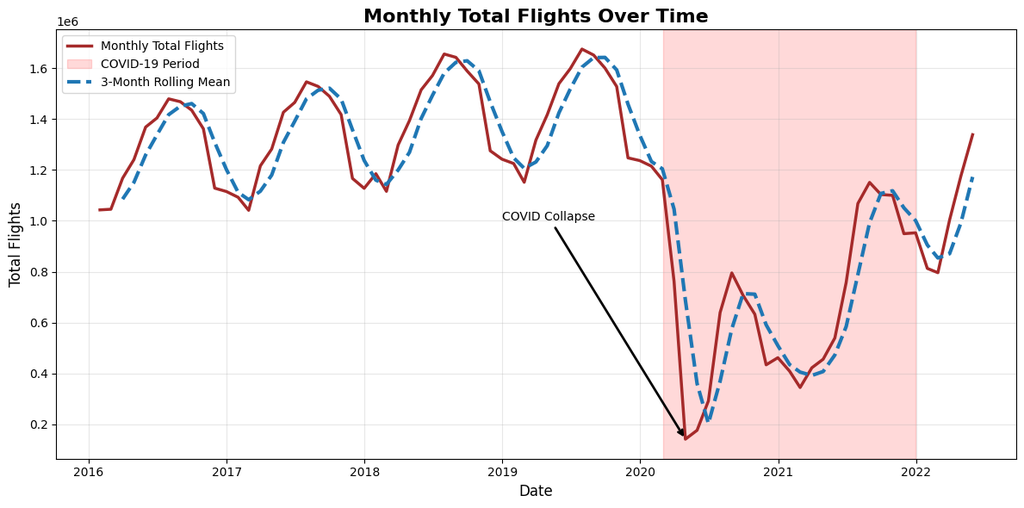

```python
monthly_flights = (
    df.groupby(
        pd.Grouper(
            key="FLT_DATE",
            freq="ME"
        )
    )["total_flights"]
    .sum()
    .reset_index()
)

plt.figure(figsize=(12, 6))
plt.plot(
    monthly_flights["FLT_DATE"],
    monthly_flights["total_flights"],
    linewidth=2.5,
    color="brown",
    label="Monthly Total Flights"
)
plt.title("Monthly Total Flights Over Time", fontsize=16, weight="bold")
plt.xlabel("Date", fontsize=12)
plt.ylabel("Total Flights", fontsize=12)
plt.grid(alpha=0.3)

plt.axvspan(
    pd.Timestamp("2020-03-01"),
    pd.Timestamp("2021-12-31"),
    color="red",
    alpha=0.15,
    label="COVID-19 Period"
)

monthly_flights["rolling_mean"] = (
    monthly_flights["total_flights"]
    .rolling(3)
    .mean()
)

plt.plot(
    monthly_flights["FLT_DATE"],
    monthly_flights["rolling_mean"],
    linewidth=3,
    linestyle="--",
    label="3-Month Rolling Mean"
)

min_idx = monthly_flights["total_flights"].idxmin()

min_x = monthly_flights.loc[min_idx, "FLT_DATE"]
min_y = monthly_flights.loc[min_idx, "total_flights"]

plt.annotate(
    "COVID Collapse",
    xy=(min_x, min_y),
    xytext=(pd.Timestamp("2019-01-01"), 1000000),
    arrowprops=dict(arrowstyle="->", lw=2)
)

import matplotlib.dates as mdates

plt.gca().xaxis.set_major_locator(
    mdates.YearLocator()
)

plt.gca().xaxis.set_major_formatter(
    mdates.DateFormatter('%Y')
)

plt.legend()

plt.tight_layout()

filepath = os.path.join("plots", "monthly_flights_over_time.png")
plt.savefig(filepath, dpi=300, bbox_inches="tight", facecolor="white")
plt.show()
```

European flight activity showed a clear seasonal pattern before COVID-19. From 2016–2019, flights consistently increased toward mid-year and usually peaked around July before declining toward the end of the year.

A major disruption occurred in early 2020 when COVID-19 caused a dramatic collapse in air traffic across Europe. After the pandemic, flight patterns became more unstable and less predictable compared to the relatively consistent pre-pandemic cycles.

The 3-month rolling mean also confirms both the repeating seasonal trend before COVID-19 and the significant disruption caused by the pandemic.

### 3.8 Which countries' flights are most affected by Covid-19?

```python
import plotly.express as px

top_8_countries = (
    df.groupby("country")["total_flights"]
    .sum()
    .nlargest(8)
    .index
)

filtered_df = df[
    df["country"].isin(top_8_countries)
]

monthly_country = (
    filtered_df.groupby(
        ["country",
         pd.Grouper(
             key="FLT_DATE",
             freq="ME"
         )]
    )["total_flights"]
    .sum()
    .reset_index()
)

fig = px.line(
    monthly_country,
    x="FLT_DATE",
    y="total_flights",
    color="country",
    title="Top 8 Countries Flight Trends Over Time",

    hover_data={
        "country": True,
        "FLT_DATE": False,
        "total_flights": ":,.0f"
    }
)

fig.update_layout(
    xaxis_title="Date",
    yaxis_title="Total Flights",
    template="plotly_white",
    hovermode="x unified"
)

fig.show()

filepath = os.path.join(
    "plots",
    "top8_countries_flights.html"
)

fig.write_html(filepath)
```

[output not shown]

### 3.9 Peak Month Per Year

```python
monthly_total = (
    df.groupby(
        pd.Grouper(
            key="FLT_DATE",
            freq="ME"
        )
    )["total_flights"]
    .sum()
    .reset_index()
)

monthly_total["YEAR"] = (
    monthly_total["FLT_DATE"].dt.year
)

monthly_total["MONTH"] = (
    monthly_total["FLT_DATE"].dt.month_name()
)

peak_months = (
    monthly_total.loc[
        monthly_total.groupby("YEAR")[
            "total_flights"
        ].idxmax()
    ]
)

print(
    peak_months[
        ["YEAR", "MONTH", "total_flights"]
    ]
)
```

```
    YEAR    MONTH  total_flights
6   2016     July        1479337
18  2017     July        1546209
30  2018     July        1655518
42  2019     July        1675015
48  2020  January        1214726
67  2021   August        1150868
76  2022      May        1338338
```

| Year | Peak Month | Total Flights |
| --- | --- | --- |
| 2016 | July | 1,479,337 |
| 2017 | July | 1,546,209 |
| 2018 | July | 1,655,518 |
| 2019 | July | 1,675,015 |
| 2020 | January | 1,214,726 |
| 2021 | August | 1,150,868 |
| 2022 | May | 1,338,338 |

### Insight from Sections 3.8–3.9

From 2016 to 2019, European flight activity showed a strong seasonal pattern, where air traffic generally increased from the beginning of the year toward mid-year before gradually declining again near the end of the year.

Several unusual situations also appeared in later years:

- **2020** recorded its peak activity in **January**, not because of a seasonal shift, but because it was the last normal period before the COVID-19 pandemic caused a dramatic collapse in European air traffic.
- **2021** showed a different recovery pattern, where peak activity occurred in **August**, likely influenced by delayed travel recovery and changing restrictions during the pandemic period.
- **2022** recorded its peak in **May**, but the dataset only contains data up to May 2022, so this should not be interpreted as a complete yearly seasonal pattern.

Overall, the dataset reveals a clear seasonal cycle in European flights while also highlighting how extraordinary events such as COVID-19 temporarily disrupted normal aviation behavior.

### 3.10 Which airports are most affected by Covid-19 flights?

```python
top_8_airports = (
    df.groupby("airport_country")["total_flights"]
    .sum()
    .nlargest(8)
    .index
)

filtered_df = df[
    df["airport_country"].isin(top_8_airports)
]

monthly_airport_country = (
    filtered_df.groupby(
        ["airport_country",
         pd.Grouper(
             key="FLT_DATE",
             freq="ME"
         )]
    )["total_flights"]
    .sum()
    .reset_index()
)

fig = px.line(
    monthly_airport_country,
    x="FLT_DATE",
    y="total_flights",
    color="airport_country",
    title="Top 8 airports Flight Trends Over Time",

    hover_data={
        "airport_country": True,
        "FLT_DATE": False,
        "total_flights": ":,.0f"
    }
)

fig.update_layout(
    xaxis_title="Date",
    yaxis_title="Total Flights",
    template="plotly_white",
    hovermode="x unified"
)

fig.show()

filepath = os.path.join(
    "plots",
    "top8_airports_flights.html"
)

fig.write_html(filepath)
```

[output not shown]

Activity at Istanbul Ataturk Airport has decreased drastically since it has not been operating since April 2019. Meanwhile, other airports experienced a decline in early 2020 due to the Covid-19 pandemic and began to recover several months later, following the pattern that occurred in previous years.

#### 3.10.1 What happened to Türkiye?

```python
turkiye_df = df[df["country"] == "Türkiye"]

airport_trends = (
    turkiye_df.groupby(
        ["YEAR", "MONTH_NUM", "airport_name"]
    )["total_flights"]
    .sum()
    .reset_index()
)
```

```python
airport_trends["date"] = pd.to_datetime(
    airport_trends["YEAR"].astype(str) + "-" +
    airport_trends["MONTH_NUM"].astype(str)
)
```

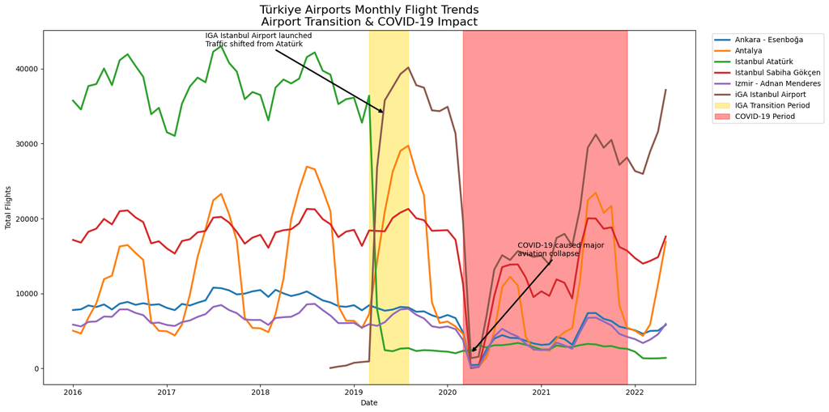

```python
plt.figure(figsize=(16, 8))

sns.lineplot(
    data=airport_trends,
    x="date",
    y="total_flights",
    hue="airport_name",
    linewidth=2.5
)

# =========================
# Highlight Transisi IGA
# =========================
plt.axvspan(
    pd.to_datetime("2019-03-01"),
    pd.to_datetime("2019-08-01"),
    color="gold",
    alpha=0.4,
    label="IGA Transition Period"
)

# =========================
# Highlight COVID
# =========================
plt.axvspan(
    pd.to_datetime("2020-03-01"),
    pd.to_datetime("2021-12-01"),
    color="red",
    alpha=0.4,
    label="COVID-19 Period"
)

# =========================
# Annotasi IGA
# =========================
plt.annotate(
    "IGA Istanbul Airport launched\nTraffic shifted from Atatürk",
    xy=(pd.to_datetime("2019-05-01"), 34000),
    xytext=(pd.to_datetime("2017-06-01"), 43000),
    arrowprops=dict(
        arrowstyle="->",
        lw=2
    ),
    fontsize=10
)

# =========================
# Annotasi COVID
# =========================
plt.annotate(
    "COVID-19 caused major\naviation collapse",
    xy=(pd.to_datetime("2020-04-01"), 2000),
    xytext=(pd.to_datetime("2020-10-01"), 15000),
    arrowprops=dict(
        arrowstyle="->",
        lw=2
    ),
    fontsize=10
)

plt.title(
    "Türkiye Airports Monthly Flight Trends\n"
    "Airport Transition & COVID-19 Impact",
    fontsize=16
)

plt.xlabel("Date")
plt.ylabel("Total Flights")

plt.legend(
    bbox_to_anchor=(1.02, 1),
    loc="upper left"
)

plt.tight_layout()

filepath = os.path.join(
    "plots",
    "turkey_airport_trends.png"
)
plt.savefig(filepath, dpi=300, bbox_inches="tight")
plt.show()
```

### What Happened to Turkish Flight Traffic?

One of the airports in Türkiye, Istanbul Atatürk, has not operated regularly since April 2019 after commercial passenger operations moved to the newer IGA Istanbul Airport.

Source: https://simpleflying.com/istanbul-ataturk-airport-fate/

### 3.11 Which airport has the highest percentage of IFR flights?

```python
top_20_airports = (
    df.groupby("airport_country")[["total_flights", "total_ifr"]]
    .sum()
    .sort_values(by="total_flights", ascending=False)
    .head(20)
)

top_20_airports["ifr_percentage"] = (
    top_20_airports["total_ifr"] /
    top_20_airports["total_flights"]
) * 100

top_20_airports
```

| airport_country | total_flights | total_ifr | ifr_percentage |
| --- | --- | --- | --- |
| Amsterdam - Schiphol (Netherlands) | 2694025 | 2691715.0 | 99.914255 |
| Paris-Charles-de-Gaulle (France) | 2581673 | 2507196.0 | 97.115165 |
| Frankfurt (Germany) | 2581524 | 2543413.0 | 98.523702 |
| London - Heathrow (United Kingdom) | 2446474 | 2332765.0 | 95.352127 |
| Madrid - Barajas (Spain) | 2117063 | 2063033.0 | 97.447879 |
| Munich (Germany) | 2013524 | 1978691.0 | 98.270048 |
| Barcelona (Spain) | 1699766 | 1659996.0 | 97.660266 |
| Istanbul Atatürk (Türkiye) | 1570488 | 0.0 | 0.000000 |
| Rome - Fiumicino (Italy) | 1518100 | 1517464.0 | 99.958106 |
| Zürich (Switzerland) | 1372321 | 1350026.0 | 98.375380 |
| London - Gatwick (United Kingdom) | 1340097 | 1317975.0 | 98.349224 |
| Copenhagen - Kastrup (Denmark) | 1335926 | 1316515.0 | 98.547000 |
| Oslo - Gardermoen (Norway) | 1326722 | 1301608.0 | 98.107064 |
| Vienna (Austria) | 1324871 | 1304647.0 | 98.473512 |
| Istanbul Sabiha Gökçen (Türkiye) | 1271627 | 0.0 | 0.000000 |
| Paris-Orly (France) | 1200973 | 1183051.0 | 98.507710 |
| Stockholm - Arlanda (Sweden) | 1198195 | 1174389.0 | 98.013178 |
| Brussels (Belgium) | 1178495 | 1191305.0 | 101.086980 |
| Dublin (Ireland) | 1161078 | 1162688.0 | 100.138664 |
| Athens (Greece) | 1133781 | 1099081.0 | 96.939444 |

### Handling Missing IFR Values

The IFR-related columns contained a large number of missing values. Instead of removing rows with missing IFR data, the missing values were filled with `0`.

This decision was made to preserve overall airport activity across different time periods. Removing rows with missing IFR values would exclude airports that may only lack IFR reporting temporarily in certain months, even though they have valid IFR activity in other periods.

For example, major airports in countries such as France, Germany, and Spain also contained missing IFR records in some observations. Dropping these rows entirely could bias the analysis by underrepresenting total airport operations.

Therefore, missing IFR values were treated as `0` under the assumption that no IFR activity was recorded for those specific observations.

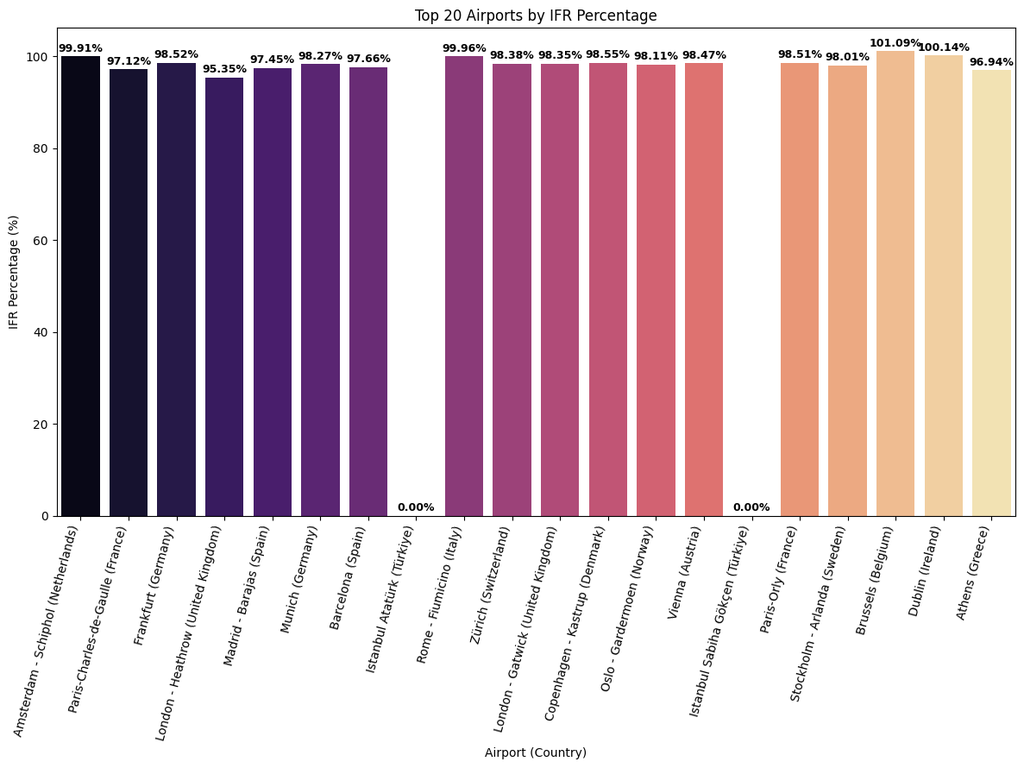

```python
plt.figure(figsize=(12, 9))

ax = sns.barplot(
    data=top_20_airports.reset_index(),
    x="airport_country",
    y="ifr_percentage",
    palette="magma"
)

plt.xticks(rotation=75, ha='right')

plt.title("Top 20 Airports by IFR Percentage")
plt.xlabel("Airport (Country)")
plt.ylabel("IFR Percentage (%)")

# Add labels
for i, value in enumerate(top_20_airports["ifr_percentage"]):
    ax.text(
        i,
        value + 0.5,
        f"{value:.2f}%",
        ha='center',
        va='bottom',
        fontsize=9,
        fontweight='bold'
    )

plt.tight_layout()

filepath = os.path.join(
    "plots",
    "top20_airports_ifr_percentage.png"
)

plt.savefig(
    filepath,
    dpi=300,
    bbox_inches="tight",
    facecolor="white"
)

plt.show()
```

Some airports exceeded 100% IFR percentage, indicating possible inconsistencies in the source dataset or differences in reporting methodology.

## 4. Key Findings

- Amsterdam Schiphol was the busiest individual airport in the dataset, but the Netherlands was not the busiest country overall. This indicates that Dutch flight activity is highly concentrated in one major hub.
- France, Germany, Spain, and the United Kingdom contributed nearly half of total European flight activity, showing that air traffic was strongly concentrated in Western Europe.
- European flights followed a clear seasonal pattern before COVID-19, generally increasing toward summer and declining near the end of the year.
- COVID-19 caused a major disruption in 2020, breaking the stable seasonal pattern seen from 2016 to 2019.
- Several major airports recovered after the initial pandemic shock, but the recovery pattern was less stable than the pre-pandemic cycle.
- Istanbul Ataturk showed a distinct structural drop after 2019 because passenger operations shifted to IGA Istanbul Airport, making it a separate event from the COVID-19 decline.
- IFR percentage results should be interpreted carefully because some airports exceeded 100%, indicating possible reporting differences or source-data inconsistencies.

## 5. Limitations

- Missing IFR values were filled with `0` to preserve airport activity records, but this can bias IFR percentage calculations downward for airports with incomplete IFR reporting.
- The dataset ends in May 2022, so 2022 should not be interpreted as a complete year when comparing annual or seasonal patterns.
- IFR percentages above 100% suggest that IFR-related columns may follow a different reporting methodology from total flight columns, or that the source data contains inconsistencies.
- This analysis focuses on descriptive EDA. It does not model causality or forecast future traffic.

## 6. Recommended Next Steps

- Compare IFR results using alternative missing-value strategies, such as leaving missing values as `NaN` or excluding airports with incomplete IFR records.
- Add airport-level recovery metrics, such as percentage decline from 2019 to 2020 and recovery rate from 2020 to 2022.
- Separate full-year comparisons from partial-year comparisons to avoid over-interpreting 2022.